# df

Autogenerated data summary from dataMaid

2025-05-28 14:44:04.639278

# Data report overview

The dataset examined has the following dimensions:

| Feature | Result |
| --- | --- |
| Number of observations | 23 |
| Number of variables | 7 |

### Checks performed

The following variable checks were performed, depending on the data type of each variable:

|  | character | factor | labelled | haven labelled | numeric | integer | logical | Date |
| --- | --- | --- | --- | --- | --- | --- | --- | --- |
| Identify miscoded missing values | $\times$ | $\times$ | $\times$ | $\times$ | $\times$ | $\times$ |  | $\times$ |
| Identify prefixed and suffixed whitespace | $\times$ | $\times$ | $\times$ | $\times$ |  |  |  |  |
| Identify levels with < 6 obs. | $\times$ | $\times$ | $\times$ | $\times$ |  |  |  |  |
| Identify case issues | $\times$ | $\times$ | $\times$ | $\times$ |  |  |  |  |
| Identify misclassified numeric or integer variables | $\times$ | $\times$ | $\times$ | $\times$ |  |  |  |  |
| Identify outliers |  |  |  |  | $\times$ | $\times$ |  | $\times$ |

Please note that all numerical values in the following have been rounded to 2 decimals.

# Summary table

[output not shown]

# Variable list

## 序號

| Feature | Result |
| --- | --- |
| Variable type | numeric |
| Number of missing obs. | 0 (0 %) |
| Number of unique values | 23 |
| Median | 12 |
| 1st and 3rd quartiles | 6.5; 17.5 |
| Min. and max. | 1; 23 |

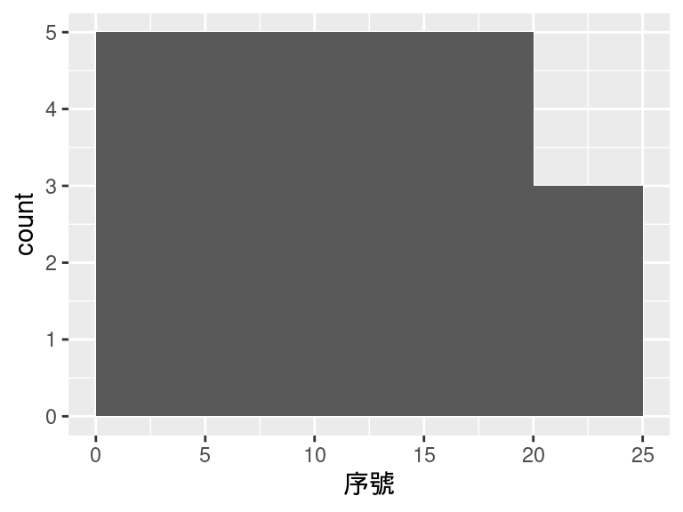

## 政事別名稱

- The variable is a key (distinct values for each observation).

## 年度預算數

| Feature | Result |
| --- | --- |
| Variable type | numeric |
| Number of missing obs. | 0 (0 %) |
| Number of unique values | 23 |
| Median | 3465285517 |
| 1st and 3rd quartiles | 1627439847.5; 10727513715.5 |
| Min. and max. | 8e+06; 63740650096 |

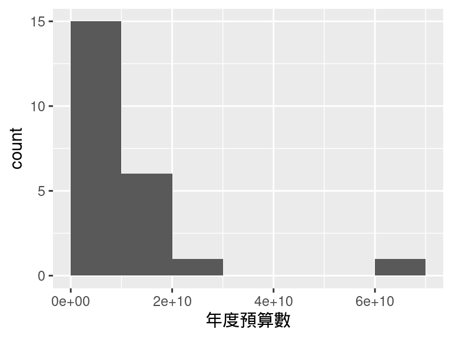

- Note that the following possible outlier values were detected: "8e+06".

## 本年分配數

| Feature | Result |
| --- | --- |
| Variable type | numeric |
| Number of missing obs. | 0 (0 %) |
| Number of unique values | 23 |
| Median | 3259939050 |
| 1st and 3rd quartiles | 1627240756.5; 10725766911.5 |
| Min. and max. | 8e+06; 63737025000 |

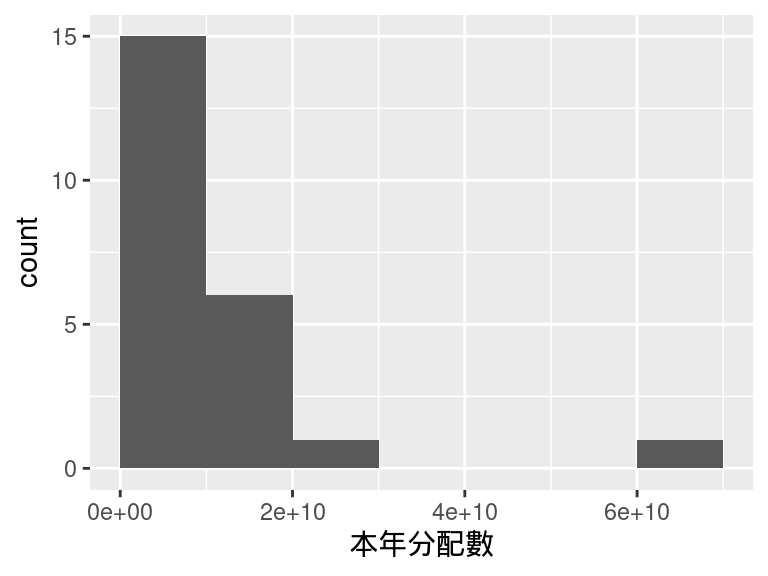

- Note that the following possible outlier values were detected: "8e+06", "448062632".

## 年度預算分配百分比

| Feature | Result |
| --- | --- |
| Variable type | numeric |
| Number of missing obs. | 0 (0 %) |
| Number of unique values | 8 |
| Median | 100 |
| 1st and 3rd quartiles | 99.97; 100 |
| Min. and max. | 56.25; 100 |

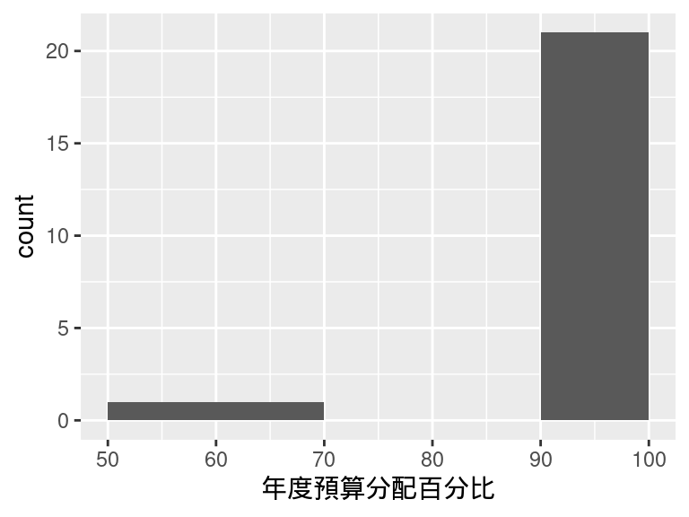

## 本年支付數

| Feature | Result |
| --- | --- |
| Variable type | numeric |
| Number of missing obs. | 0 (0 %) |
| Number of unique values | 23 |
| Median | 3084536520 |
| 1st and 3rd quartiles | 1555274050; 10059043963.5 |
| Min. and max. | 0; 63730571420 |

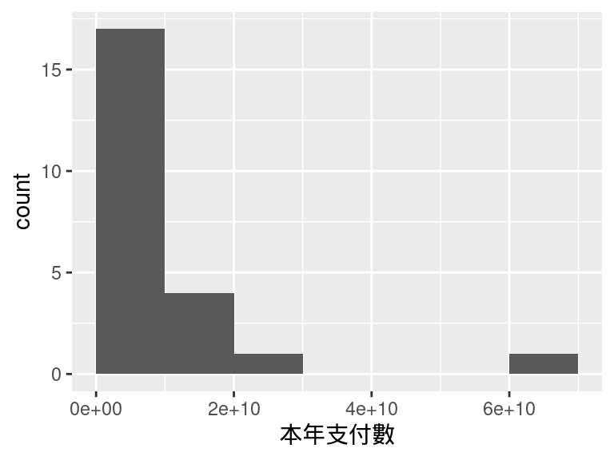

- Note that the following possible outlier values were detected: "0", "438012305".

## 分配預算支付百分比

| Feature | Result |
| --- | --- |
| Variable type | numeric |
| Number of missing obs. | 0 (0 %) |
| Number of unique values | 23 |
| Median | 94.62 |
| 1st and 3rd quartiles | 92.29; 97.06 |
| Min. and max. | 0; 99.99 |

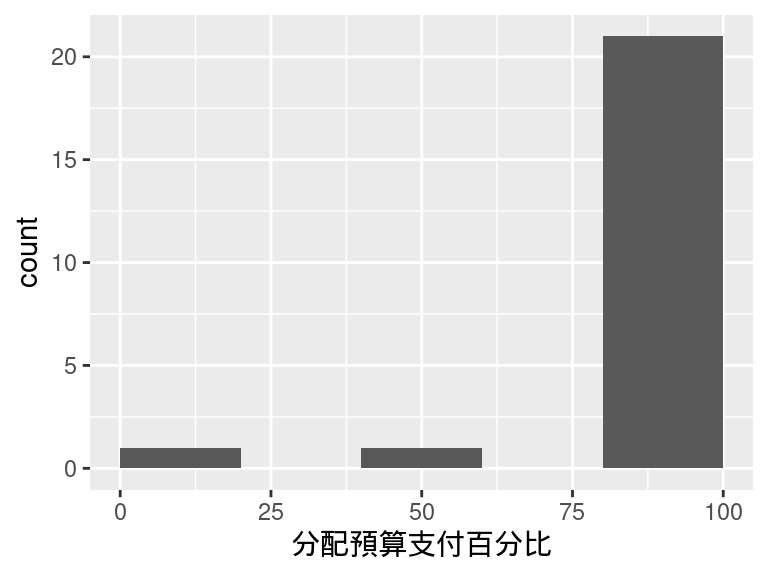

- Note that the following possible outlier values were detected: "0", "41.89".

Report generation information:

- Created by: Could not determine from system (username: `r3069585`).
- Report creation time: Wed May 28 2025 14:44:04
- Report was run from directory: `/cloud/project`
- dataMaid v1.4.2 [Pkg: 2025-04-13 from RSPM (R 4.3.0)]
- R version 4.3.3 (2024-02-29).
- Platform: x86_64-pc-linux-gnu (64-bit)(UTC).
- Function call: `dataMaid::makeDataReport(data = df, file = "codebook", replace = TRUE, filetype = "md")`